# Statistics_Python_CH6_Linear_Regression : Ravi Mummigatti 26-Dec-2020

# Introduction

Today, we are living in a world dominated by data. Thanks to impressive technology and data tracking systems, computers are capable of capturing and storing massive amounts of data. For example, a car sales company like Maruti is in a position to collect enormous amount of data on different aspects of its business, such as car sales, economy of the country, stock market prices, crude oil prices etc. Environment activists are able to record proportions of different greenhouse gases in the atmosphere in minute details and are interested in understanding how the fluctuations of these gases in different times of day in different seasons are responsible for climatic pollution and human health.

The immediate next step after data collection is data analysis and interpretation. Consider the car sales example of Maruti. The question of how the economy of a country affects car sales, and possibly vice versa, is a rather important question. For this, the industry needs to understand the dependence between car sales and various macro-economic factors. For environmentalists, knowing how the average global temperature fluctuates with fluctuations in the proportions of the greenhouse gases, is a question of crucial importance.

Also, whether there is at all any direct relation among these features, or the relationship is controlled by one or more unobserved factors, need to be objectively determined. In both the cases mentioned above, it is required to provide a definitive relationship between the **variable of interest (or response)** and the **other variables (or predictors)** which are used to understand it. This helps in clarifying the dependence between the variables concerned.

Another very important aspect of data analysis, particularly in the above two examples cited, is prediction. Maruti would like to predict car sales for future, given the expected measure of economy growth or recession that year, so that it can take informed decisions regarding its business. Similarly, environmentalists would be interested in knowing how reduction in global warming will be effected by decreasing concentrations of the greenhouse gases and by how much. For both these objectives, one needs to form a model which explicitly relates the response to the predictors

We will understand the various aspects of Linear Regression through a case study and various examples.The case study involves Regressing alcohol percentage on the chemical components present in various wines

Regression analysis is primarily used for two conceptually distinct purposes.  
First, regression analysis is widely used for prediction and forecasting, where its use has substantial overlap with the field of machine learning.  
Second, in some situations regression analysis can be used to infer causal relationships between the independent and dependent variables. Importantly, regressions by themselves only reveal relationships between a dependent variable and a collection of independent variables in a fixed dataset. To use regressions for prediction or to infer causal relationships, respectively, a researcher must carefully justify why existing relationships have predictive power for a new context or why a relationship between two variables has a causal interpretation  
(https://en.wikipedia.org/wiki/Regression_analysis)

# What is Regression

Regression is a statistical method used in finance, investing, and other disciplines that attempts to determine the **strength and character of the relationship** between one dependent variable (usually denoted by Y) and a series of other variables (known as independent variables)

**Two important terms in regression:**

- Response, Outcome, or Dependent variable (y): The variable of interest that one wants to model or predict using one or more variables whose values are known.
- Predictor, Explanatory, Feature or Independent variables(x) : It is assumed that the response depends on one or more predictors. These variables are independent and a model is formulated identifying the explicit relationship between the response and the predictor(s).

**Types of Regression:**

1. Simple linear regression : Summarize and study relationships between two continuous (quantitative) variables
2. Multiple linear regression : Summrize and study relationships between one continuous response and multiple predictor variables

Simple linear regression gets its adjective "simple," because it concerns the study of only one predictor variable. In contrast, multiple linear regression gets its adjective "multiple," because it concerns the study of two or more predictor variables

# Case Study / Business Understanding

A top wine manufacturer wants to invest in new technologies to improve its wine quality.  
Wine quality is directly dependent on the amount of alcohol in wines and the smoothness which, in turn, are controlled by various chemicals either directly added during the manufacturing process or generated through various chemical reactions.  
Wine certification and quality assessment are key elements for wine gradation and its price ticket. Wine certification is determined by various physiochemical elements in the wine. Therefore, the company wants to estimate the percentage (%) of alcohol in a bottle of wine as a function of various chemical components of the wine.

**Statement of the Problem: Regress alcohol percentage on the chemical components present in the wines.**

**Description of the data (Data Dictionary)**

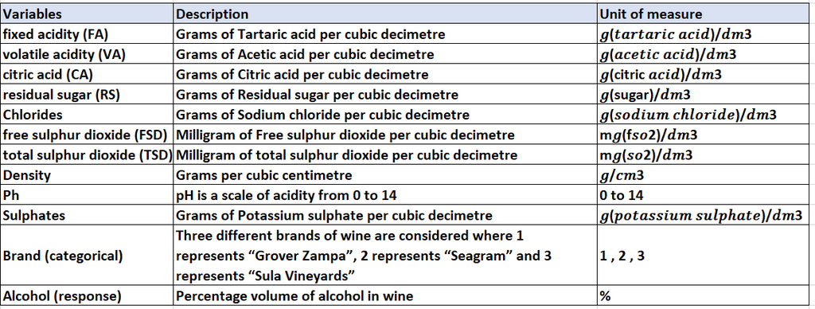

# What is Pairwise Correlation

Before a regression model of alcohol on the predictors can be built, it is necessary to investigate whether there exists any dependence among the observed variables.

**Formal definition of Correlation**: The pairwise correlation coefficient (denoted as 𝑟) measures the degree of relatedness between two variables. The correlation coefficient (𝑟) developed by *Karl Pearson* is termed as Pearson product-moment correlation coefficient.  
The term 𝑟 is a measure of the strength and the direction of the linear relationship between **two continuous** variables

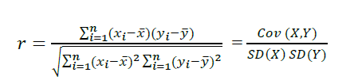

Here, 𝑋 and 𝑌 are the pair of attributes measured on 𝑛 units. From the i-th unit a pair of observations (𝑥𝑖, 𝑦𝑖) is obtained, and 𝑥̅ and 𝑦̅ are the respective means. The value of 𝑟 ranges from −1 to +1, both values included.

In general, there is no nice practical operational interpretation for r.You can only use r to make a statement about the strength of the linear relationship between x and y. In general:

- If r = -1, then there is a perfect negative linear relationship between x and y.If (x, y) pairs are plotted, the points would fall on a straight line with negative slope. This indicates that X and Y are perfectly linearly related but, if one variable increases, the other decreases
- If r = 1, then there is a perfect positive linear relationship between x and y.If (x, y) pairs are plotted, the points would fall on a straight line with positive slope. This indicates that X and Y are perfectly linearly related and if one variable increases, the other also increases.
- If r = 0, then there is no linear relationship between x and y.

All other values of r tell us that the relationship between x and y is not perfect.The closer r is to 0, the weaker the linear relationship.The closer r is to -1, the stronger the negative linear relationship.And, the closer r is to 1, the stronger the positive linear relationship.

The plot of (x, y) continous variable pairs is known as a scatterplot.  
In the plots below , the 1st scatterplot corresponding to r = 0 clearly shows that there is no discernible pattern in the plot. The other two scatterplots exhibit moderate correlations of equal magnitude (0.6) but in opposite directions.

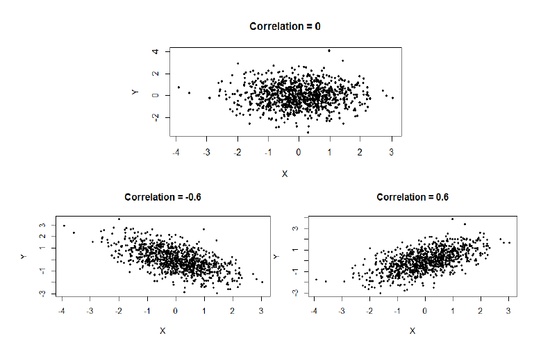

# Case Study 1 : Correlation

Objective : Determine whether any dependence exists between alcohol (%) and three selected chemical components, FA, pH and density individually.

```python
## import the required packages
import pandas as pd
import numpy as np
import seaborn as sns
import matplotlib.pyplot as plt
from scipy import stats
import warnings
warnings.filterwarnings('ignore')
%matplotlib inline
sns.set()
```

## Exploratory Data Analysis

```python
## load the data
df = pd.read_csv("wine_data.csv")
df.info()
```

```
<class 'pandas.core.frame.DataFrame'>
RangeIndex: 1599 entries, 0 to 1598
Data columns (total 13 columns):
 #   Column    Non-Null Count  Dtype
---  ------    --------------  -----
 0   ID        1599 non-null   int64
 1   Brand     1599 non-null   object
 2   FA        1599 non-null   float64
 3   VA        1599 non-null   float64
 4   CA        1599 non-null   float64
 5   RS        1599 non-null   float64
 6   chloride  1599 non-null   float64
 7   FSD       1599 non-null   float64
 8   TSD       1599 non-null   float64
 9   density   1599 non-null   float64
 10  pH        1599 non-null   float64
 11  sulphate  1599 non-null   float64
 12  alcohol   1599 non-null   float64
dtypes: float64(11), int64(1), object(1)
memory usage: 162.5+ KB
```

```python
df.head()
```

|  | ID | Brand | FA | VA | CA | RS | chloride | FSD | TSD | density | pH | sulphate | alcohol |
| --- | --- | --- | --- | --- | --- | --- | --- | --- | --- | --- | --- | --- | --- |
| 0 | 1 | Seagram | 7.4 | 0.70 | 0.00 | 1.9 | 0.076 | 11.0 | 34.0 | 0.9978 | 3.51 | 0.56 | 9.4 |
| 1 | 2 | Seagram | 7.8 | 0.88 | 0.00 | 2.6 | 0.098 | 25.0 | 67.0 | 0.9968 | 3.20 | 0.68 | 9.8 |
| 2 | 3 | Seagram | 7.8 | 0.76 | 0.04 | 2.3 | 0.092 | 15.0 | 54.0 | 0.9970 | 3.26 | 0.65 | 9.8 |
| 3 | 4 | Sula Vineyards | 11.2 | 0.28 | 0.56 | 1.9 | 0.075 | 17.0 | 60.0 | 0.9980 | 3.16 | 0.58 | 9.8 |
| 4 | 5 | Seagram | 7.4 | 0.70 | 0.00 | 1.9 | 0.076 | 11.0 | 34.0 | 0.9978 | 3.51 | 0.56 | 9.4 |

```python
df.describe().T
```

|  | count | mean | std | min | 25% | 50% | 75% | max |
| --- | --- | --- | --- | --- | --- | --- | --- | --- |
| ID | 1599.0 | 800.000000 | 461.735855 | 1.00000 | 400.5000 | 800.00000 | 1199.500000 | 1599.00000 |
| FA | 1599.0 | 8.319637 | 1.741096 | 4.60000 | 7.1000 | 7.90000 | 9.200000 | 15.90000 |
| VA | 1599.0 | 0.527821 | 0.179060 | 0.12000 | 0.3900 | 0.52000 | 0.640000 | 1.58000 |
| CA | 1599.0 | 0.270976 | 0.194801 | 0.00000 | 0.0900 | 0.26000 | 0.420000 | 1.00000 |
| RS | 1599.0 | 2.538806 | 1.409928 | 0.90000 | 1.9000 | 2.20000 | 2.600000 | 15.50000 |
| chloride | 1599.0 | 0.087467 | 0.047065 | 0.01200 | 0.0700 | 0.07900 | 0.090000 | 0.61100 |
| FSD | 1599.0 | 15.874922 | 10.460157 | 1.00000 | 7.0000 | 14.00000 | 21.000000 | 72.00000 |
| TSD | 1599.0 | 46.467792 | 32.895324 | 6.00000 | 22.0000 | 38.00000 | 62.000000 | 289.00000 |
| density | 1599.0 | 0.996747 | 0.001887 | 0.99007 | 0.9956 | 0.99675 | 0.997835 | 1.00369 |
| pH | 1599.0 | 3.311113 | 0.154386 | 2.74000 | 3.2100 | 3.31000 | 3.400000 | 4.01000 |
| sulphate | 1599.0 | 0.658149 | 0.169507 | 0.33000 | 0.5500 | 0.62000 | 0.730000 | 2.00000 |
| alcohol | 1599.0 | 10.422983 | 1.065668 | 8.40000 | 9.5000 | 10.20000 | 11.100000 | 14.90000 |

```python
df['Brand'].value_counts()
```

```
Seagram           633
Sula Vineyards    553
Grover Zampa      413
Name: Brand, dtype: int64
```

**Inference**

**Visually Exploring Pairwise Correlations**

```python
## create a dataframe with FA , pH , density and alcohol only
df2 = df[['FA' , 'pH' , 'density' , 'alcohol']]
df2.describe()
```

|  | FA | pH | density | alcohol |
| --- | --- | --- | --- | --- |
| count | 1599.000000 | 1599.000000 | 1599.000000 | 1599.000000 |
| mean | 8.319637 | 3.311113 | 0.996747 | 10.422983 |
| std | 1.741096 | 0.154386 | 0.001887 | 1.065668 |
| min | 4.600000 | 2.740000 | 0.990070 | 8.400000 |
| 25% | 7.100000 | 3.210000 | 0.995600 | 9.500000 |
| 50% | 7.900000 | 3.310000 | 0.996750 | 10.200000 |
| 75% | 9.200000 | 3.400000 | 0.997835 | 11.100000 |
| max | 15.900000 | 4.010000 | 1.003690 | 14.900000 |

**PAIR PLOT WITH CORRELATION CO-EFFICIENTS**

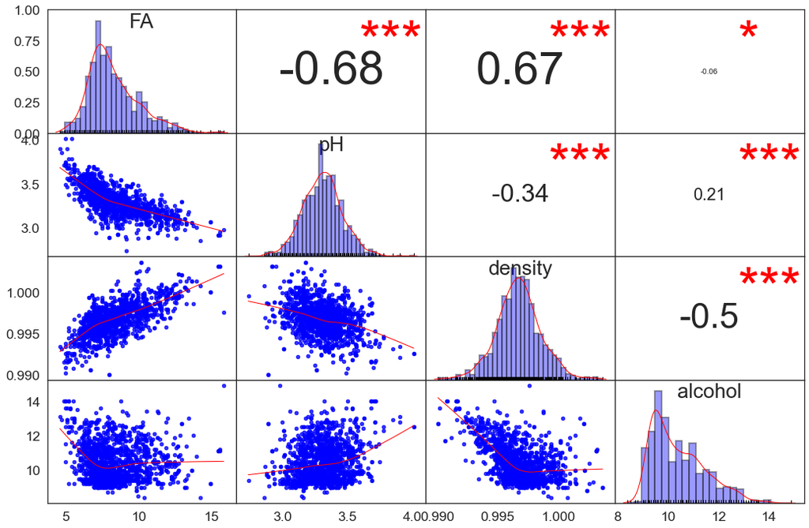

```python
def corrdot(*args, **kwargs):
    corr_r = args[0].corr(args[1], 'pearson')
    corr_text = round(corr_r, 2)
    ax = plt.gca()
    font_size = abs(corr_r) * 80 + 5
    ax.annotate(corr_text, [.5, .5,],  xycoords="axes fraction",
                ha='center', va='center', fontsize=font_size)

def corrfunc(x, y, **kws):
    r, p = stats.pearsonr(x, y)
    p_stars = ''
    if p <= 0.05: ## Statistically significant @ alpha = 0.05
        p_stars = '*'
    if p <= 0.01: ## Statistically significant @ alpha = 0.01
        p_stars = '**'
    if p <= 0.001: ## Statistically significant @ alpha = 0.01
        p_stars = '***'
    ax = plt.gca()
    ax.annotate(p_stars, xy=(0.65, 0.6), xycoords=ax.transAxes,
                color='red', fontsize=70)

sns.set(style='white', font_scale=1.6)
g = sns.PairGrid(df2, aspect=1.5, diag_sharey=False, despine=False)
g.map_lower(sns.regplot, lowess=True, ci=False,
            line_kws={'color': 'red', 'lw': 1},
            scatter_kws={'color': 'blue', 's': 20})
g.map_diag(sns.distplot, color='black',
           kde_kws={'color': 'red', 'cut': 0.7, 'lw': 1},
           hist_kws={'histtype': 'bar', 'lw': 2,
                     'edgecolor': 'k', 'facecolor':'blue'})
g.map_diag(sns.rugplot, color='black')
g.map_upper(corrdot)
g.map_upper(corrfunc)
g.fig.subplots_adjust(wspace=0, hspace=0)

# Remove axis labels
for ax in g.axes.flatten():
    ax.set_ylabel('')
    ax.set_xlabel('')

# Add titles to the diagonal axes/subplots
for ax, col in zip(np.diag(g.axes), df2.columns):
    ax.set_title(col, y=0.82, fontsize=26)
```

## Conclusion

1. Correlation between alcohol Fixed Acidity ) is 𝑟=−0.062 , indicating a negative dependence which is statistically significant. For all practical purpose correlation between alcohol and FA is taken to be non-existent.
2. Correlation between alcohol and pH is 𝑟=0.21 , indicating a positive dependence which is statistically significant.For all practical purpose correlation between alcohol and pH is taken to be weak.
3. Correlation between alcohol and density is 𝑟=−0.50 , indicating a moderate dependence between alcohol and density and implying that as density increases, alcohol (%) reduces.

## Important Note :

Correlation is only useful in determining linear relationship between two variables. Zero correlation may imply no linear dependence, but that does not preclude any other form of dependence (such as, polynomial) between the variables concerned.

Further, correlation does not indicate any cause and effect relationship. Correlation simply quantifies how well two variables are related, if at all, and its direction (i.e. positive or negative).

Another important observation about correlation is that, even when correlation is significantly different from zero (the * in correlation chart indicates precisely that), it may not have any practical significance.

Typically, the rule of thumb for correlation values is as follows:

1. r between −0.4 and +0.4 indicates absence of linear dependence
2. r between −0.7 and −0.4 or r between +0.4 and +0.7 indicates moderate linear dependence, the sign indicating its direction
3. r less than −0.7 or r greater than +0.7 indicates strong linear dependence

# Simple Linear Regression

## Definition

**The formal definition of Simple Linear Regression:** Let n pairs of observations (𝑥𝑖, 𝑦𝑖), i = 1, 2, …, n, be available on two features, one of which is assumed to depend on the other. Typically Y denotes the dependent variable and X the independent variable. Let the quantity 𝐸(𝑌) denote the expected or mean value of 𝑌.

**Simple linear regression relates the response Y to the single predictor variable X through a straight line. The mathematical formulation of the simple linear regression line is: 𝐸(𝑌)=𝛽0 +𝛽1 𝑋**

- 𝑌: is the value of the continuous response (or dependent) variable
- 𝛽0 and 𝛽1: are intercept and slope coefficients, respectively, and known as the regression parameters.
- 𝑋: represents the independent (predictor) variable continuous in nature.

It is assumed that the expected value of the response is a linear function of the predictor.

When 𝛽0 and 𝛽1are known, a given value of the predictor will specify the expected value of the response.However, since Y is a random variable, not all values 𝑦𝑖 will be equal to 𝐸(𝑌).

**Another form of SLR equation is 𝑌𝑖=𝛽0 +𝛽1 𝑋𝑖 + 𝜀𝑖, i = 1, 2, …,n**  
𝜖: represents the unobservable error term. Note that error here does not indicate any mistake, simply the difference between the expected and observed values of the response.The error terms provide crucial insight into the regression process.

## Case Study 2 : Dependence of alcohol on density

The objective here is to determine the dependence of alcohol (%) on density. Though any one of the 10 continuous predictors may have been used as predictor, the choice is made based on a higher correlation between the response and the predictor

### Correlation

```python
# calculate Pearson's correlation
from scipy.stats import pearsonr
corr, _ = pearsonr(df['alcohol'], df['density'])
print('Pearsons correlation between alcohol and density: %.3f' % corr)

# Statistical Significance
pearsonr(df['alcohol'], df['density'])
print('p-value of Pearsonc Correlation is ~0 indicating a significant correlation at 95% confidence')
```

```
Pearsons correlation between alcohol and density: -0.496
p-value of Pearsonc Correlation is ~0 indicating a significant correlation at 95% confidence
```

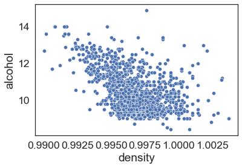

```python
# scatter plot of alcohol v/s density
sns.scatterplot(data=df , x = df["density"] , y = df["alcohol"]);
```

The scatterplot above suggests that a linear relationship between alcohol and density may exist since the majority of the points seem to fall on a straight line.The correlation between alcohol (%) and density is ~ −0.5.We also expect the slope to be negative i.e. increase in density is expected to decrease alcohol (%).  
We will now fit a linear regression model with alcohol (%) as the response and density as the predictor.

### Fitting a Simple Regression Line

**REGRESSION WITH STATSMODEL**

**Step1 : Import package**

```python
import statsmodels.api as sm
```

**Step2 : Create the Feature and Dependent Variables**

```python
## Creating array of Feature X
X= df[['density']]

## Creating the array of Target y
y = df[['alcohol']]
```

**Step3 : Adding the Constant**  
By default, statsmodels fits a line passing through the origin, i.e. it doesn't fit an intercept. Hence, you need to use thecommand 'add_constant' so that it also fits an intercept.

```python
# add constant
X = sm.add_constant(X)
```

**Step4 : Fit the OLS Regression Model**  
We call the .fit() method to fit a model

```python
# fit the OLS Linear Regression model
Smodel = sm.OLS(y, X).fit()
```

**Step5 : Model Summary**

```python
# model summary
Smodel.summary()
```

OLS Regression Results

| Dep. Variable: | alcohol | R-squared: | 0.246 |
| --- | --- | --- | --- |
| Model: | OLS | Adj. R-squared: | 0.246 |
| Method: | Least Squares | F-statistic: | 521.6 |
| Date: | Sat, 26 Dec 2020 | Prob (F-statistic): | 3.94e-100 |
| Time: | 18:20:10 | Log-Likelihood: | -2144.1 |
| No. Observations: | 1599 | AIC: | 4292. |
| Df Residuals: | 1597 | BIC: | 4303. |
| Df Model: | 1 |  |  |
| Covariance Type: | nonrobust |  |  |

|  | coef | std err | t | P>\|t\| | [0.025 | 0.975] |
| --- | --- | --- | --- | --- | --- | --- |
| const | 289.6753 | 12.227 | 23.691 | 0.000 | 265.692 | 313.659 |
| density | -280.1638 | 12.267 | -22.838 | 0.000 | -304.226 | -256.102 |

| Omnibus: | 147.785 | Durbin-Watson: | 1.460 |
| --- | --- | --- | --- |
| Prob(Omnibus): | 0.000 | Jarque-Bera (JB): | 193.960 |
| Skew: | 0.768 | Prob(JB): | 7.62e-43 |
| Kurtosis: | 3.743 | Cond. No. | 1.06e+03 |

Notes:  
[1] Standard Errors assume that the covariance matrix of the errors is correctly specified.  
[2] The condition number is large, 1.06e+03. This might indicate that there are  
strong multicollinearity or other numerical problems.

1. R-squared reflects the fit of the model which range from 0 to 1, where a higher value generally indicates a better fit, assuming certain conditions are met.
2. const coefficient is your Y-intercept. It means that if Density coefficient is zero, then the expected output (i.e., the Y) would be equal to the const coefficient.
3. Density coefficient represents the change in the output Y(% alcohol) due to a change of one unit in the Density (everything else held constant)
4. std err reflects the level of accuracy of the coefficients. The lower it is, the higher is the level of accuracy
5. P >|t| is your p-value. A p-value of less than 0.05 is considered to be statistically significant
6. Confidence Interval represents the range in which our coefficients are likely to fall (with a likelihood of 95%)

**Step7 : Regression Equation & Interpretation**

**Est(Alcohol%) = 289.675 - 280(Density)**

We first note that the sign of 𝛽̂1 is negative. This shows that the two variables are inversely related, i.e. if one increases, the other decreases. This confirms our expectation that the variables alcohol (%) and density increase/decrease in opposite directions and we get a straight line with negative slope.

**The sign of the regression slope and the correlation coefficient will always be the same.**

The regression slope is the measure of change in the response with one unit change in predictor and it's sign indicates the direction of the change.

The value of 𝛽̂1 indicates that if density increases by 1 unit, the estimated alcohol (%) decreases by 280.16 unit.

However, the response being in percentage, its values are bounded between 0 and 100. So is our interpretation misleading? Actually, from the EDA, it can be seen that the minimum and maximum values of density are mostly between 0.99 and 1.00. Hence the range of density is approximately 0.01.

While interpreting a regression parameter, it is important to pay heed to the range of values of the predictor. In this case density cannot be expected to change by 1 unit, but the changes in the density will be in the order of 1/1000.

Hence, the following statement will be appropriate in this case: **If density increases by 0.001 unit, then alcohol (%) decreases by 0.28 unit.**

The intercept term is the estimated value of the response when the predictor is 0. However, the intercept term is not always interpretable, such as in this case.

**Step6 : Plot the Model**

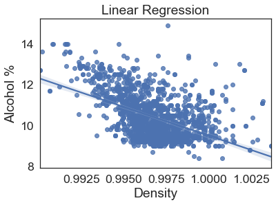

```python
import seaborn as sns
ax=sns.regplot(x='density', y='alcohol', data=df)
ax.set_ylabel("Alcohol %")
ax.set_xlabel("Density")
ax.set_title("Linear Regression")
plt.show();
```

Let us look at alcohol (%) in the wines at several levels of density

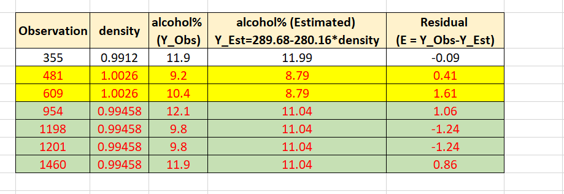

It is clear from the above table that the pairs (Xi, Yobs) is not unique but (Xi,Yest) are At a given level of density, there may be several observed values of alcohol (%).  
When density is 0.99458, alcohol content may range from 9.8% to 12.1%.  
On the other hand, 11.9% alcohol may be found when density is 0.9912 as well as when density is 0.99458.  
However, estimated alcohol content is uniquely defined through the regression equation for a given value of density.

**The difference between the observed and fitted values of the response is called residual. Residuals may be both positive or negative**

# Assumptions of OLS Regression

The linear regression model is defined on 4 important assumptions, often referred to as **(LINE)**

**1: Linear Function -- The mean of the response E(Yi) at each value of the predictor (Xi) is a Linear Function of the (Xi).Alternatively mean of the error E(𝜖i) at each value of the predicto (xi) is "Zero"**

**2: Independent -- The error terms 𝜖𝑖 are Independent**

**3: Normally Distributed -- The error variables 𝜖𝑖 at each value of the predictor xi are Normally distributed.**

**4: Equal Variances (σ)^2-- The errors have no bias (that is, 𝐸(𝜖𝑖)=0) and they are homoscedastic, i.e. The errors(𝜖𝑖) at each value of the predictor(xi) have Equal Variance.**

**A simpler to describe all four assumptions is that the errors 𝜖𝑖 are independent normal random variables with mean zero and constant variance(σ)^2.**

# Statistical significance of regression model

## Significance of regression slope

Estimating the regression coefficients is only the first step of regression model fitting.  
OLS will produce estimates of regression intercept and regression slope given any sample data. However, it is of vital importance to know whether the population regression slope is significantly different from 0. If in the population the regression slope is not significantly different from 0, then there is no regression of Y on X.

**We now need to know, is density at all statistically significant in explaining alcohol (%)?**

We follow standard hypothesis test procedures in conducting a hypothesis test for the slope.  
**Null Hypothesis (H0) : 𝛽1=0**  
**Alternate Hypothesis (HA) : 𝛽1≠0**  
*where 𝛽1 is the regression coefficient of density when alcohol (%) is regressed on density*

```python
# model summary
Smodel.summary()
```

OLS Regression Results

| Dep. Variable: | alcohol | R-squared: | 0.246 |
| --- | --- | --- | --- |
| Model: | OLS | Adj. R-squared: | 0.246 |
| Method: | Least Squares | F-statistic: | 521.6 |
| Date: | Sat, 26 Dec 2020 | Prob (F-statistic): | 3.94e-100 |
| Time: | 18:20:11 | Log-Likelihood: | -2144.1 |
| No. Observations: | 1599 | AIC: | 4292. |
| Df Residuals: | 1597 | BIC: | 4303. |
| Df Model: | 1 |  |  |
| Covariance Type: | nonrobust |  |  |

|  | coef | std err | t | P>\|t\| | [0.025 | 0.975] |
| --- | --- | --- | --- | --- | --- | --- |
| const | 289.6753 | 12.227 | 23.691 | 0.000 | 265.692 | 313.659 |
| density | -280.1638 | 12.267 | -22.838 | 0.000 | -304.226 | -256.102 |

| Omnibus: | 147.785 | Durbin-Watson: | 1.460 |
| --- | --- | --- | --- |
| Prob(Omnibus): | 0.000 | Jarque-Bera (JB): | 193.960 |
| Skew: | 0.768 | Prob(JB): | 7.62e-43 |
| Kurtosis: | 3.743 | Cond. No. | 1.06e+03 |

Notes:  
[1] Standard Errors assume that the covariance matrix of the errors is correctly specified.  
[2] The condition number is large, 1.06e+03. This might indicate that there are  
strong multicollinearity or other numerical problems.

Observe that the p-value corresponding to density**(P>|t|~0.00)** is very small and thus the null hypothesis 𝐻0:𝛽1=0 is rejected which in turn indicates that density is significant in explaining alcohol(%)

**Inference :**  
**We conclude "there is sufficient evidence at a 95% confidence level to conclude that there is a linear relationship in the population between the predictor x (density) and response y (alcohol%).**

Statistical significance alone, is not enough to decide whether the predictor is useful in explaining the variability in the response. In this case , is density enough to explain a large part of variation in alcohol?  
This leads us to the concept of **coefficient of determination 𝑅2**

## The Coefficient of Determination 𝐑𝟐

**The coefficient of determination R2 is a summary measure that explains how well the sample regression line fits the data.**  
The rationale and computation of R2 is discussed below: Let 𝑌𝑖̂=𝛽̂0+𝛽̂1𝑋𝑖 and 𝑌̅=1𝑛Σ𝑌𝑖𝑛𝑖=1. 𝑌𝑖̂ is the estimated value of the response, for a given value of the predictor 𝑋𝑖. Reviewing the Fitted Model Plot and Estimated Values we notice that not all predicted values of the response will be equal to the observed value 𝑌𝑖. In fact it may well happen that none of the estimated values of the response coincides with the corresponding observed values.

The difference between the observed and the estimated values of the response is called residual. Residual is the estimated value of the unobserved error component in the regression equation.𝜖̂𝑖 = 𝑌𝑖 - 𝑌̂𝑖

Residuals are very important part of regression and they have many useful properties.

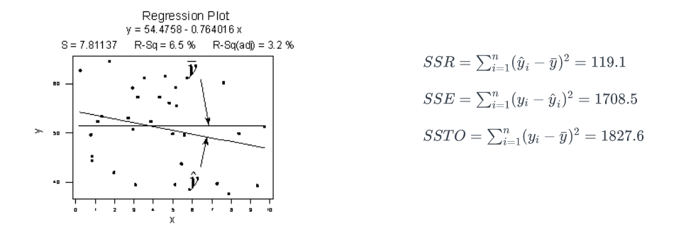

1. SSR is the "regression sum of squares" and quantifies how far the estimated sloped regression line (y^),is from the horizontal "no relationship line," the sample mean or (ybar)
2. SSE is the "error sum of squares" and quantifies how much the data points(yi)vary around the estimated regression line (y^)
3. SSTO/SST is the "total sum of squares" and quantifies how much the data points (yi, vary around their mean or (ybar)

Note! that SSTO = SSR + SSE. The sums of squares appear to tell the story pretty well. They tell us that most of the variation in the response y (SSTO = 1827.6) is just due to random variation (SSE = 1708.5), not due to the regression of y on x (SSR = 119.1). You might notice that SSR divided by SSTO is 119.1/1827.6 or 0.065

**The "coefficient of determination" or "r-squared value," denoted R2, is the regression sum of squares divided by the total sum of squares**

**R2=(𝑆𝑆𝑅/𝑆𝑆𝑇) or R2=1−(𝑆𝑆𝐸/𝑆𝑆𝑇)**

The numerical value of 𝑅2 is equal to the square of the correlation coefficient between the response and the predictor only if there is a single predictor in the linear regression model, i.e. for simple linear regression only.

1. 𝑅2 measures the proportion of the total variation in 𝑌 that is explained by the regression model.
2. 𝑅2 ranges from 0≤𝑅2≤1. The higher the value of 𝑅2, the more powerful is the predictor to predict the response.
3. A regression model with high 𝑅2 value indicates that the model fits the data well. In that case a high proportion of variance in the response is explained by the dependence of the response on the predictor

**Interpreting 𝑅2 for our SLR Model**  
For the current model, the value of 𝑅2 turns out to be approximately 25% . This means, density is able to explain around 25% of the total variation in alcohol (%).

It is clear that, even though, the regression of alcohol (%) on density is significant (p-value < 0.05), density by itself is not sufficient to explain the variation in the response to a satisfactory degree.

## R2 Cautions

**Caution 1**  
The coefficient of determination r2 and the correlation coefficient r quantify the strength of a linear relationship. It is possible that r2 = 0% and r = 0, suggesting there is no linear relation between x and y, and yet a perfect curved (or "curvilinear" relationship) exists.

**Caution 2** A large r2 value should not be interpreted as meaning that the estimated regression line fits the data well. Another function might better describe the trend in the data.

**Caution 3** The coefficient of determination r2 and the correlation coefficient r can both be greatly affected by just one data point (or a few data points) i.e. sensitive outliers and leverage points.

**Caution 4** Correlation (or association) does not imply causation. Association between the predictor x and response y should not be interpreted as implying that x causes the changes in y. There are many possible reasons for why there is an association between x and y, including:

- The predictor x does indeed cause the changes in the response y.
- The causal relation may instead be reversed. That is, the response y may cause the changes in the predictor x.
- The predictor x is a contributing but not sole cause of changes in the response variable y.
- There may be a "lurking variable" that is the real cause of changes in y but also is associated with x, thus giving rise to the observed relationship between x and y.
- The association may be purely coincidental

**Caution 5** A "statistically significant" r2 value does not imply that the slope β1 is meaningfully different from 0.

In general, the larger the data set, the easier it is to reject the null hypothesis and claim "statistical significance." If the data set is very large, it is even possible to reject the null hypothesis and claim that the slope β1 is not 0, even when it is not practically or meaningfully different from 0. It is possible to get a significant P-value when β1 is 0.13, a quantity that is likely not to be considered meaningfully different from 0. The key here is that "statistical significance does not imply practical significance."

**Caution 6** A large r2 value does not necessarily mean that a useful prediction of the response ynew, or estimation of the mean response μY, can be made. It is still possible to get prediction intervals or confidence intervals that are too wide to be useful.

## Residual Plots

Residuals are estimated errors and are defined as 𝜖̂𝑖=𝑌𝑖−𝑌̂𝑖. Residuals have many important properties and are employed to check various regression assumptions. Recall that "Sum of Residuals = 0" When conducting a residual analysis, a **residuals versus fits plot** is the most frequently created plot. It is a scatter plot of residuals on the y axis and fitted values (estimated responses) on the x axis.  
**The residulas versus fitted plot is used to detect non-linearity, unequal error variances, and outliers.**

1. If the assumptions (Section7) of linear regression are satisfied, the residuals will form a band around the 0 line when plotted against the fitted values. The residuals should be randomly distributed around the horizontal line (that represents zero residual errors) i.e. there should not be a distinct trend in the distribution of points.
2. If the scatterplot shows any systematic deviations from this band shape, they may indicate various departures from the assumptions. For example, if the residuals show any funnel-out or funnel-in shape, then one may conclude that the error variances are not all equal. If the scatterplot shows sinusoidal pattern, that may indicate serial dependence among the observations.

**Charateristics of a well-behaved residual vs. fits plot and what they suggest about the appropriateness of the simple linear regression model:**

1. The residuals "bounce randomly" around the residual = 0 line. This suggests that the assumption that the relationship is linear is reasonable.
2. The residuals roughly form a "horizontal band" around the residual = 0 line. This suggests that the variances of the error terms are equal.
3. No one residual "stands out" from the basic random pattern of residuals. This suggests that there are no outliers

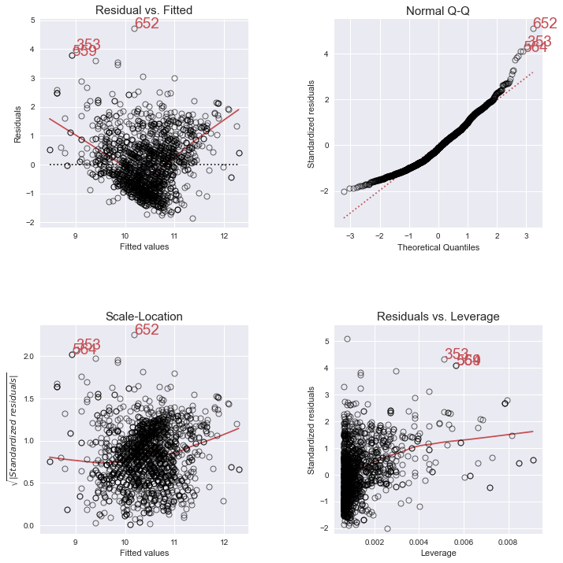

```python
# import lmdiag package
import lmdiag
# plot the diagnostic plots
plt.style.use('seaborn')
plt.figure(figsize=(10,10))
lmdiag.plot(Smodel)
plt.show();
```

It is clear from the discussions above that density, in spite of having significant slope when alcohol (%) is regressed on it, can explain only 25% of the total variability in the response. It is a natural step then to examine whether inclusion of the other predictors contribute towards explanation of the variability in the response, and if so, to what degree.

## Example : Lung Function in 6 to 10 Year Old Children

The variables to consider are :

y = forced exhalation volume (FEV), a measure of how much air somebody can forcibly exhale from their lungs  
x = age in years.

Data source: The data here are a part of a dataset given in Kahn, Michael (2005). "An Exhalent Problem for Teaching Statistics", The Journal of Statistical Education, 13(2).

Objective : We want to study the relationship between forced exhalation volume (FEV), a measure of how much air one can forcibly exhale, and age (in years).

```python
# load the data
fev_df = pd.read_csv("fev_dat.csv")
fev_df.describe()
```

|  | age | FEV | ht | sex | smoke |
| --- | --- | --- | --- | --- | --- |
| count | 654.000000 | 654.000000 | 654.000000 | 654.000000 | 654.000000 |
| mean | 9.931193 | 2.636780 | 61.143578 | 0.513761 | 0.099388 |
| std | 2.953935 | 0.867059 | 5.703513 | 0.500193 | 0.299412 |
| min | 3.000000 | 0.791000 | 46.000000 | 0.000000 | 0.000000 |
| 25% | 8.000000 | 1.981000 | 57.000000 | 0.000000 | 0.000000 |
| 50% | 10.000000 | 2.547500 | 61.500000 | 1.000000 | 0.000000 |
| 75% | 12.000000 | 3.118500 | 65.500000 | 1.000000 | 0.000000 |
| max | 19.000000 | 5.793000 | 74.000000 | 1.000000 | 1.000000 |

```python
## create a dataframe with Respose : FEV and Predictor : Age only
fev = fev_df[['age' , 'FEV']]
fev.describe()
```

|  | age | FEV |
| --- | --- | --- |
| count | 654.000000 | 654.000000 |
| mean | 9.931193 | 2.636780 |
| std | 2.953935 | 0.867059 |
| min | 3.000000 | 0.791000 |
| 25% | 8.000000 | 1.981000 |
| 50% | 10.000000 | 2.547500 |
| 75% | 12.000000 | 3.118500 |
| max | 19.000000 | 5.793000 |

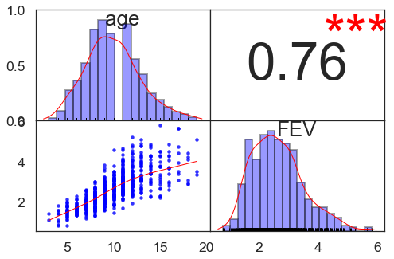

```python
# Pair Plot Of Correlations
def corrdot(*args, **kwargs):
    corr_r = args[0].corr(args[1], 'pearson')
    corr_text = round(corr_r, 2)
    ax = plt.gca()
    font_size = abs(corr_r) * 80 + 5
    ax.annotate(corr_text, [.5, .5,],  xycoords="axes fraction",
                ha='center', va='center', fontsize=font_size)

def corrfunc(x, y, **kws):
    r, p = stats.pearsonr(x, y)
    p_stars = ''
    if p <= 0.05: ## Statistically significant @ alpha = 0.05
        p_stars = '*'
    if p <= 0.01: ## Statistically significant @ alpha = 0.01
        p_stars = '**'
    if p <= 0.001: ## Statistically significant @ alpha = 0.01
        p_stars = '***'
    ax = plt.gca()
    ax.annotate(p_stars, xy=(0.65, 0.6), xycoords=ax.transAxes,
                color='red', fontsize=70)

sns.set(style='white', font_scale=1.6)
g = sns.PairGrid(fev, aspect=1.5, diag_sharey=False, despine=False)
g.map_lower(sns.regplot, lowess=True, ci=False,
            line_kws={'color': 'red', 'lw': 1},
            scatter_kws={'color': 'blue', 's': 20})
g.map_diag(sns.distplot, color='black',
           kde_kws={'color': 'red', 'cut': 0.7, 'lw': 1},
           hist_kws={'histtype': 'bar', 'lw': 2,
                     'edgecolor': 'k', 'facecolor':'blue'})
g.map_diag(sns.rugplot, color='black')
g.map_upper(corrdot)
g.map_upper(corrfunc)
g.fig.subplots_adjust(wspace=0, hspace=0)

# Remove axis labels
for ax in g.axes.flatten():
    ax.set_ylabel('')
    ax.set_xlabel('')

# Add titles to the diagonal axes/subplots
for ax, col in zip(np.diag(g.axes), fev.columns):
    ax.set_title(col, y=0.82, fontsize=26)
```

```python
## Correlation Test
## calculate Pearson's correlation
from scipy.stats import pearsonr
# Statistical Significance
pearsonr(fev['FEV'], fev['age'])
```

```
(0.7564589899895997, 2.4539601903511364e-122)
```

```python
# Fit a Linear Regression Model with X=Age and y=FEV

## Creating array of Feature X
X= fev[['age']]

## Creating the array of Target y
y = fev[['FEV']]

# add constant
X = sm.add_constant(X)

# fit the OLS Linear Regression model
Fevmodel = sm.OLS(y, X).fit()

# model summary
Fevmodel.summary()
```

OLS Regression Results

| Dep. Variable: | FEV | R-squared: | 0.572 |
| --- | --- | --- | --- |
| Model: | OLS | Adj. R-squared: | 0.572 |
| Method: | Least Squares | F-statistic: | 872.2 |
| Date: | Sat, 26 Dec 2020 | Prob (F-statistic): | 2.45e-122 |
| Time: | 18:20:18 | Log-Likelihood: | -556.51 |
| No. Observations: | 654 | AIC: | 1117. |
| Df Residuals: | 652 | BIC: | 1126. |
| Df Model: | 1 |  |  |
| Covariance Type: | nonrobust |  |  |

|  | coef | std err | t | P>\|t\| | [0.025 | 0.975] |
| --- | --- | --- | --- | --- | --- | --- |
| const | 0.4316 | 0.078 | 5.541 | 0.000 | 0.279 | 0.585 |
| age | 0.2220 | 0.008 | 29.533 | 0.000 | 0.207 | 0.237 |

| Omnibus: | 35.892 | Durbin-Watson: | 1.608 |
| --- | --- | --- | --- |
| Prob(Omnibus): | 0.000 | Jarque-Bera (JB): | 51.347 |
| Skew: | 0.454 | Prob(JB): | 7.08e-12 |
| Kurtosis: | 4.030 | Cond. No. | 36.7 |

Notes:  
[1] Standard Errors assume that the covariance matrix of the errors is correctly specified.

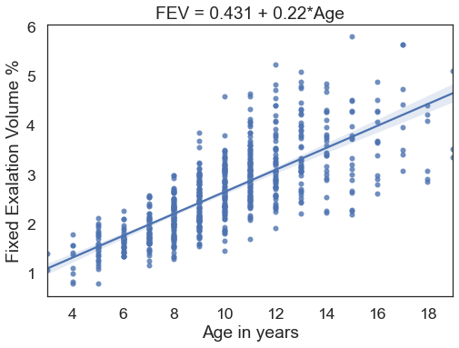

```python
import seaborn as sns
ax=sns.regplot(y='FEV', x='age', data=fev)
ax.set_ylabel("Fixed Exalation Volume %")
ax.set_xlabel("Age in years")
ax.set_title("FEV = 0.431 + 0.22*Age")
plt.show();
```

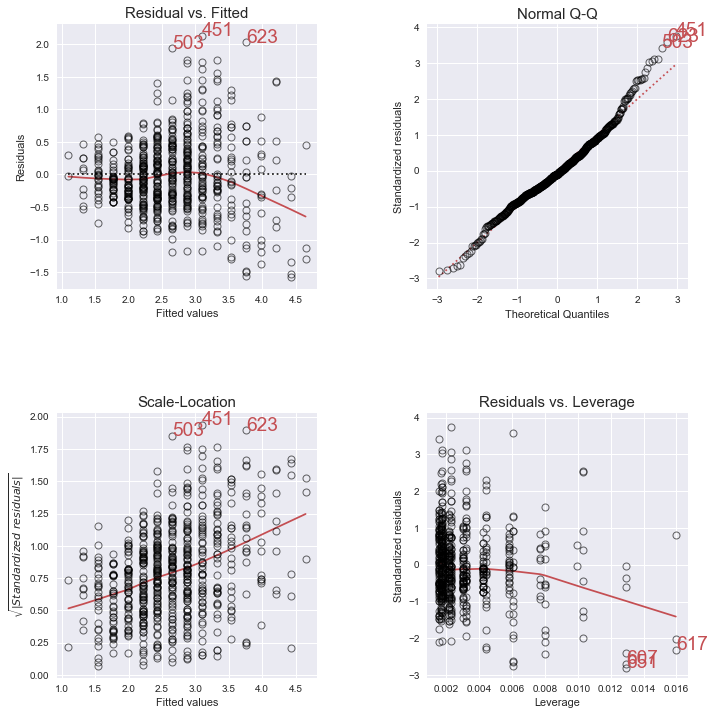

```python
# import lmdiag package
import lmdiag
# plot the diagnostic plots
plt.style.use('seaborn')
plt.figure(figsize=(10,10))
lmdiag.plot(Fevmodel)
plt.show();
```

**Interpretation**

(1) The interpretation of the slope (value = 0.22) is that average FEV increases 0.22 for each one year increase in age (in the observed age range).

(2) The estimated regression equation is that average FEV = 0.431 + 0.22*Age.

(3) The r-squared (R2=0.572) means Age “explains” 57.2% of the observed variation in the average FEV in the observed age range

(4) Correlation coefficient r = 0.76 with p value is < 0.05 implying that FEV and Age are strongly correlated in the observed age range

(5) An interesting feature of these data is that the variance of individual y-values from the regression line increases as age increases. This feature of data is called non-constant variance. For example, the FEV values of 10-year-olds are more variable than FEV value of 6-year-olds. This is seen by looking at the vertical ranges of the data in the plot. This may lead to problems using a simple linear regression model for these data

## Example : Car Sales Promotion

We consider another example of sales revenue of a retail company and the sales promotion expenses

### Step 1 : Data Collection

```python
# load the data
sales = pd.read_csv("sales_promotion.csv")
```

### Step 2 : Data Pre-processing

In this important step, data is checked to ensure the quality of the data for issues including, correctness, completeness, usefulness, relevance, missing data and extreme values.

```python
sales.head()
```

|  | Revenue | Sales_Promotion |
| --- | --- | --- |
| 0 | 78.61 | 38.5140 |
| 1 | 41.25 | 19.0952 |
| 2 | 19.15 | 8.4174 |
| 3 | 40.52 | 22.0857 |
| 4 | 41.61 | 20.4118 |

```python
sales.info()
```

```
<class 'pandas.core.frame.DataFrame'>
RangeIndex: 50 entries, 0 to 49
Data columns (total 2 columns):
 #   Column           Non-Null Count  Dtype
---  ------           --------------  -----
 0   Revenue          50 non-null     float64
 1   Sales_Promotion  50 non-null     float64
dtypes: float64(2)
memory usage: 928.0 bytes
```

```python
sales.isnull().sum().sum()
```

```
0
```

**Inference :**

1. There are 50 rows and two columns in the data frame
2. The two column names are Revenue and Sales Promotion
3. There are "No Missing Values"

### Step 3 : Descriptive Analytics

1. Boxplot to show if there are any outliers in the data; the how the quartiles are distributed.
2. Scatter plot to show any obvious relationship between the dependent and independent variables

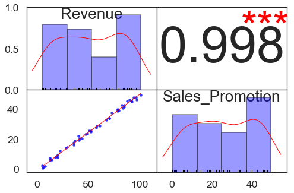

```python
# Pair Plot Of Correlations
def corrdot(*args, **kwargs):
    corr_r = args[0].corr(args[1], 'pearson')
    corr_text = round(corr_r, 3)
    ax = plt.gca()
    font_size = abs(corr_r) * 80 + 5
    ax.annotate(corr_text, [.5, .5,],  xycoords="axes fraction",
                ha='center', va='center', fontsize=font_size)

def corrfunc(x, y, **kws):
    r, p = stats.pearsonr(x, y)
    p_stars = ''
    if p <= 0.05: ## Statistically significant @ alpha = 0.05
        p_stars = '*'
    if p <= 0.01: ## Statistically significant @ alpha = 0.01
        p_stars = '**'
    if p <= 0.001: ## Statistically significant @ alpha = 0.01
        p_stars = '***'
    ax = plt.gca()
    ax.annotate(p_stars, xy=(0.65, 0.6), xycoords=ax.transAxes,
                color='red', fontsize=70)

sns.set(style='white', font_scale=1.6)
g = sns.PairGrid(sales, aspect=1.5, diag_sharey=False, despine=False)
g.map_lower(sns.regplot, lowess=True, ci=False,
            line_kws={'color': 'red', 'lw': 1},
            scatter_kws={'color': 'blue', 's': 20})
g.map_diag(sns.distplot, color='black',
           kde_kws={'color': 'red', 'cut': 0.7, 'lw': 1},
           hist_kws={'histtype': 'bar', 'lw': 2,
                     'edgecolor': 'k', 'facecolor':'blue'})
g.map_diag(sns.rugplot, color='black')
g.map_upper(corrdot)
g.map_upper(corrfunc)
g.fig.subplots_adjust(wspace=0, hspace=0)

# Remove axis labels
for ax in g.axes.flatten():
    ax.set_ylabel('')
    ax.set_xlabel('')

# Add titles to the diagonal axes/subplots
for ax, col in zip(np.diag(g.axes), sales.columns):
    ax.set_title(col, y=0.82, fontsize=26)
```

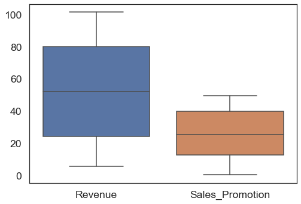

```python
sns.boxplot(data=sales);
```

**Inference :**

1. Boxplot shows no outliers in Revenue and Sales
2. Scatter plot reveals a positive Linear relationship.
3. Correlation co-efficient of 0.998 revelas a strong correlation between Revenue and Sales Promotion

### Step 4 : Fit OLS Regression Model

```python
## Creating array of Feature X
X= sales[['Sales_Promotion']]

## Creating the array of Target y
y = sales[['Revenue']]

# add constant
X = sm.add_constant(X)

# fit the OLS Linear Regression model
Salesmodel = sm.OLS(y, X).fit()

# model summary
Salesmodel.summary()
```

OLS Regression Results

| Dep. Variable: | Revenue | R-squared: | 0.996 |
| --- | --- | --- | --- |
| Model: | OLS | Adj. R-squared: | 0.995 |
| Method: | Least Squares | F-statistic: | 1.064e+04 |
| Date: | Sat, 26 Dec 2020 | Prob (F-statistic): | 5.19e-58 |
| Time: | 18:20:22 | Log-Likelihood: | -105.69 |
| No. Observations: | 50 | AIC: | 215.4 |
| Df Residuals: | 48 | BIC: | 219.2 |
| Df Model: | 1 |  |  |
| Covariance Type: | nonrobust |  |  |

|  | coef | std err | t | P>\|t\| | [0.025 | 0.975] |
| --- | --- | --- | --- | --- | --- | --- |
| const | 2.2566 | 0.568 | 3.971 | 0.000 | 1.114 | 3.399 |
| Sales_Promotion | 1.9689 | 0.019 | 103.158 | 0.000 | 1.931 | 2.007 |

| Omnibus: | 1.011 | Durbin-Watson: | 2.179 |
| --- | --- | --- | --- |
| Prob(Omnibus): | 0.603 | Jarque-Bera (JB): | 0.994 |
| Skew: | -0.316 | Prob(JB): | 0.608 |
| Kurtosis: | 2.722 | Cond. No. | 58.6 |

Notes:  
[1] Standard Errors assume that the covariance matrix of the errors is correctly specified.

### Step 5 : Significance Tests for Fitted Model

**Null Hypothesis (H0) : 𝛽1=0**  
**Alternate Hypothesis (HA) : 𝛽1≠0**

Observe that the p-value corresponding to Sales_Promotion(P>|t|~0.00) is very small and thus the null hypothesis 𝐻0:𝛽1=0 is rejected which in turn indicates that Sales_Promotion is significant in explaining Revenue

**Inference : There is sufficient evidence at a 95% confidence level to conclude that there is a linear relationship in the population between the predictor x (Sales_Promotion) and response y (Revenue).**

### Step 6 : Regression Equation & Strength of the model

**β0 = 2.2526; β1 = 1.9689**  
**Confidence Intervale for Estimate : 1.931 to 2.007** **R2 : 0.996**  
**Estimated Revenue = 2.256 + 1.969(Sales_Promotion)**

**Inference : We are 95% confident that the expected number of sales revenue is between 1.93 and 2.01 higher for each unit increase in promotion expenses and the model explains 99.6% of the variation in the dependent variable Revenue.**

### Step 7 : Plot the fitted model

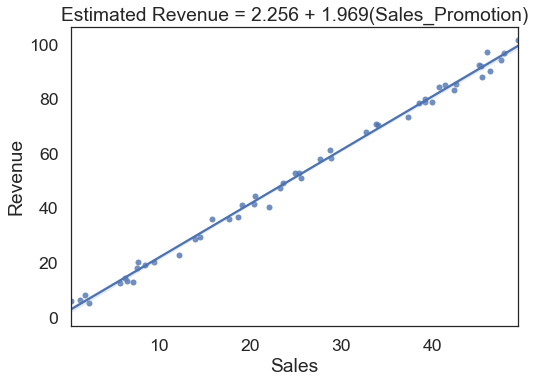

```python
import seaborn as sns
ax=sns.regplot(x='Sales_Promotion', y='Revenue', data=sales)
ax.set_ylabel("Revenue")
ax.set_xlabel("Sales")
ax.set_title("Estimated Revenue = 2.256 + 1.969(Sales_Promotion)")
plt.show();
```

### Validate Model Assumptions with Plots

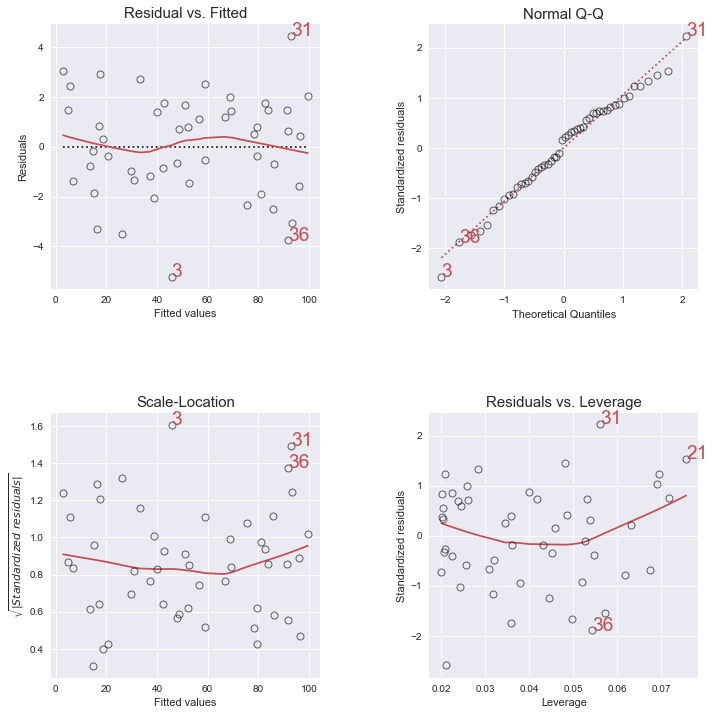

```python
# import lmdiag package
import lmdiag
# plot the diagnostic plots
plt.style.use('seaborn')
plt.figure(figsize=(10,10))
lmdiag.plot(Salesmodel)
plt.show();
```

**1) Linearity of the data : Residual vs fitted plot :** Examining the Residuals v/s Fitted Plot we infer a fairly linear relationship between Revenue at each value of the Sales Promotion with "Mean Zero"

**2) Normality of Residuals : Normal Q-Q plot :** Examining the Q-Q Plot we infer that the residuals are failry Normally Distributed. We shall use Shapiro test to confirm the same..

```python
import scipy.stats as stats
stats.shapiro(Salesmodel.resid)
```

```
ShapiroResult(statistic=0.9852102994918823, pvalue=0.7806096076965332)
```

**Since the p-value > 0.05, the null hypothesis that the errors are normally distributed cannot be rejected at 5% significance level and we connclude that "Errors Are Normally Distributed"**

**3) Homogeneity of Variance : Scale-Location plot :** Examining the Q-Q Plot we infer that the residuals have a constant variance. We will the BP test.  
**The null hypothesis (H0): Homoscedasticity is present.**  
**The alternative hypothesis: (Ha): Homoscedasticity is not present (i.e. heteroscedasticity exists)**

```python
sm.stats.diagnostic.het_breuschpagan(Salesmodel.resid , Salesmodel.model.exog)
```

```
(0.050088767213868346,
 0.8229088841635135,
 0.04813343541414922,
 0.8272739671647992)
```

**4) Absence of Outliers : Residuals v/s Leverage plot :** Inspecting the Residuals v/s Leverage plot , we conclude that the data does not show any influential points. Cook’s distance lines (a red dashed line) are not shown on the Residuals vs Leverage plot because all points are well inside of the Cook’s distance lines.

# Multiple Linear Regression (MLR)

In the previous sections we have investigated how one single predictor variable may be used to predict a response. In reality, the response depends on multiple variables. For example, the volume of car sales of a company depends not only on the GDP but also on other factors like crude oil prices, confidence index of the population and many other considerations. In general, the response variable is found to depend on several predictors simultaneously.

Multiple linear regression is one of the simplest statistical tools that is used to analyse the relationship of the response with several predictors. Like simple linear regression, this procedure fits a linear function of the predictors to the response.

## Definition :

The formal definition of Multiple Linear Regression: Multiple regression is a statistical technique used to analyse relationship between a single dependent variable and several predictors simultaneously. Assume n (multivariate) sample observations (𝑥1𝑖, 𝑥2𝑖, …𝑥𝑘𝑖, 𝑦𝑖), i = 1, 2, …, n, are available. Y denotes the dependent variable and 𝑋1, 𝑋2, …,𝑋𝑘 the independent variables.

The mathematical formulation of multiple linear regression line is: **𝐸(𝑌)=𝛽0 +𝛽1 𝑋1+𝛽2𝑋2+⋯+𝛽𝑘𝑋𝑘**

- 𝑌: is the value of the continuous response (or dependent) variable,
- 𝛽0 : is the intercept
- 𝑋𝑗: represents the 𝑗𝑡ℎ independent (predictor) variable continuous in nature. j = 1, …, k
- 𝛽𝑗: represents the coefficient of the 𝑗𝑡ℎ independent (predictor) variable.

It is assumed that the expected value of the response is a linear function of all the k predictors.  
When the regression coefficients 𝛽0 and 𝛽𝑗,𝑗 = 1,…,𝑘 are all known, or estimated, a given value of the predictor combination will specify the expected value of the response.

Another form of MLR equation is **𝑌𝑖=𝛽0 +𝛽1 𝑋1𝑖+𝛽2𝑋2𝑖+⋯+𝛽𝑘𝑋𝑘𝑖 + 𝜀𝑖, i = 1, 2, …,n** 𝜀: represents the unobservable error term.

Formally the parameters 𝛽1,𝛽2,…,𝛽𝑘 are called **partial regression coefficients**, since the coefficient 𝛽𝑘 measures the change in the value of the response due to unit change in the value of 𝑋𝑘, keeping all other variables fixed.  
We will refer to the 𝛽0 ,𝛽1,𝛽2,…,𝛽𝑘 simply as regression coefficients.

## The method of Ordinary Least Squares

As in the case of simple linear regression , in multiple regression also the regression coefficients are estimated by minimizing the error sum of squares

## Case Study 3 :

Now we consider **all the physiochemical liquids together** and evaluate the regression model that would predict the alcohol (%) in wine.

### Summarize the data (summary statistics)

```python
# summarize the data
df.describe(include = 'all').T
```

|  | count | unique | top | freq | mean | std | min | 25% | 50% | 75% | max |
| --- | --- | --- | --- | --- | --- | --- | --- | --- | --- | --- | --- |
| ID | 1599 | NaN | NaN | NaN | 800 | 461.736 | 1 | 400.5 | 800 | 1199.5 | 1599 |
| Brand | 1599 | 3 | Seagram | 633 | NaN | NaN | NaN | NaN | NaN | NaN | NaN |
| FA | 1599 | NaN | NaN | NaN | 8.31964 | 1.7411 | 4.6 | 7.1 | 7.9 | 9.2 | 15.9 |
| VA | 1599 | NaN | NaN | NaN | 0.527821 | 0.17906 | 0.12 | 0.39 | 0.52 | 0.64 | 1.58 |
| CA | 1599 | NaN | NaN | NaN | 0.270976 | 0.194801 | 0 | 0.09 | 0.26 | 0.42 | 1 |
| RS | 1599 | NaN | NaN | NaN | 2.53881 | 1.40993 | 0.9 | 1.9 | 2.2 | 2.6 | 15.5 |
| chloride | 1599 | NaN | NaN | NaN | 0.0874665 | 0.0470653 | 0.012 | 0.07 | 0.079 | 0.09 | 0.611 |
| FSD | 1599 | NaN | NaN | NaN | 15.8749 | 10.4602 | 1 | 7 | 14 | 21 | 72 |
| TSD | 1599 | NaN | NaN | NaN | 46.4678 | 32.8953 | 6 | 22 | 38 | 62 | 289 |
| density | 1599 | NaN | NaN | NaN | 0.996747 | 0.00188733 | 0.99007 | 0.9956 | 0.99675 | 0.997835 | 1.00369 |
| pH | 1599 | NaN | NaN | NaN | 3.31111 | 0.154386 | 2.74 | 3.21 | 3.31 | 3.4 | 4.01 |
| sulphate | 1599 | NaN | NaN | NaN | 0.658149 | 0.169507 | 0.33 | 0.55 | 0.62 | 0.73 | 2 |
| alcohol | 1599 | NaN | NaN | NaN | 10.423 | 1.06567 | 8.4 | 9.5 | 10.2 | 11.1 | 14.9 |

```python
# Exclude Brand for now
df_num = df.loc[:, df.columns != 'Brand']
df_num.info()
```

```
<class 'pandas.core.frame.DataFrame'>
RangeIndex: 1599 entries, 0 to 1598
Data columns (total 12 columns):
 #   Column    Non-Null Count  Dtype
---  ------    --------------  -----
 0   ID        1599 non-null   int64
 1   FA        1599 non-null   float64
 2   VA        1599 non-null   float64
 3   CA        1599 non-null   float64
 4   RS        1599 non-null   float64
 5   chloride  1599 non-null   float64
 6   FSD       1599 non-null   float64
 7   TSD       1599 non-null   float64
 8   density   1599 non-null   float64
 9   pH        1599 non-null   float64
 10  sulphate  1599 non-null   float64
 11  alcohol   1599 non-null   float64
dtypes: float64(11), int64(1)
memory usage: 150.0 KB
```

### Correlations

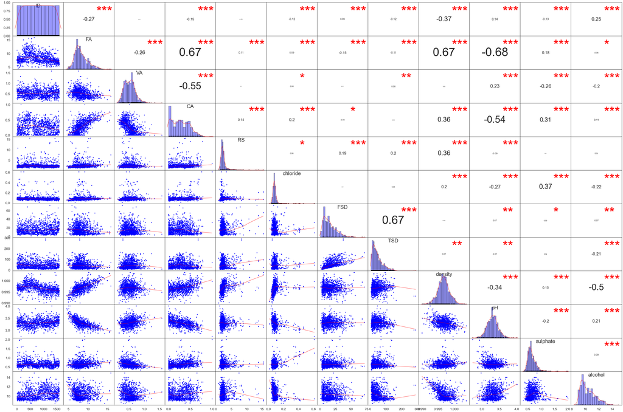

```python
# Pair Plot Of Correlations
def corrdot(*args, **kwargs):
    corr_r = args[0].corr(args[1], 'pearson')
    corr_text = round(corr_r, 2)
    ax = plt.gca()
    font_size = abs(corr_r) * 80 + 5
    ax.annotate(corr_text, [.5, .5,],  xycoords="axes fraction",
                ha='center', va='center', fontsize=font_size)

def corrfunc(x, y, **kws):
    r, p = stats.pearsonr(x, y)
    p_stars = ''
    if p <= 0.05: ## Statistically significant @ alpha = 0.05
        p_stars = '*'
    if p <= 0.01: ## Statistically significant @ alpha = 0.01
        p_stars = '**'
    if p <= 0.001: ## Statistically significant @ alpha = 0.01
        p_stars = '***'
    ax = plt.gca()
    ax.annotate(p_stars, xy=(0.65, 0.6), xycoords=ax.transAxes,
                color='red', fontsize=70)

sns.set(style='white', font_scale=1.6)
g = sns.PairGrid(df_num, aspect=1.5, diag_sharey=False, despine=False)
g.map_lower(sns.regplot, lowess=True, ci=False,
            line_kws={'color': 'red', 'lw': 1},
            scatter_kws={'color': 'blue', 's': 20})
g.map_diag(sns.distplot, color='black',
           kde_kws={'color': 'red', 'cut': 0.7, 'lw': 1},
           hist_kws={'histtype': 'bar', 'lw': 2,
                     'edgecolor': 'k', 'facecolor':'blue'})
g.map_diag(sns.rugplot, color='black')
g.map_upper(corrdot)
g.map_upper(corrfunc)
g.fig.subplots_adjust(wspace=0, hspace=0)

# Remove axis labels
for ax in g.axes.flatten():
    ax.set_ylabel('')
    ax.set_xlabel('')

# Add titles to the diagonal axes/subplots
for ax, col in zip(np.diag(g.axes), df_num.columns):
    ax.set_title(col, y=0.82, fontsize=26)
```

### Dealing with Categorical Variables

Before the problem of fitting a multiple linear regression model is taken up, the case of categorical predictor needs to be explicitly discussed. So far we have tacitly assumed that the response as well as the predictors are all continuous.Let us discuss the situation when one or more predictors are categorical.  
A set of **dummy variables or indicator variables** is introduced corresponding to each categorical variable.  
**A discrete variable with 𝑚 categories is represented by a set of 𝑚−1 dummy variables.**

**Indicator coding / One-Hot-Coding : It is the most common format of dummy variable coding in which each category of the nominal variable is represented by either 1 or 0.**

Let us now look at how Indicator Variables impact the regression equation:  
If 𝑋1,…,𝑋𝑘 are continuous then we can write the regression model of 𝑌 on 𝑋 as: 𝑌=𝛽0 +𝛽1𝑋1+⋯+𝛽𝑘𝑋𝑘+𝜖  
When we have a predictor variable 𝑋 that is is a categorical variable with 𝑚 levels, a small modification is required for the above regression model.  
In our case , Brand is a categorical predictor with three levels Grover Zampa, Seagram and Sula Vineyards. Hence 𝑚−1=3−1=2 i.e. TWO DUMMY VARIABLES need to be introduced in the model.The model equation now is written as  
**𝑌=𝛽0+𝛽1𝑋1+⋯+𝛽𝑘𝑋𝑘+𝛽𝑘+1𝐷1+𝛽𝑘+2𝐷2+𝜖 where 𝐷1 and 𝐷2 are dummy variables taking values 1 or 0 as per the observation representation.**

**Charateristics of Dummy Variables :**

1. A dummy variable (aka indicator variable) is an variable artificially created to represent an attribute with two or more distinct levels / categories.
2. Since Regression Analysis treats all independent variables in the analysis as numeric variables, we need dummy variables created for categorical variables.
3. Dummy variables assign numbers 0 or 1 to indicate membership to the category which is mutually exclusive and exhaustive.
4. The number of dummy variables necessary to represent a single attribute variable is equal to the number of levels minus 1.
5. One dummy variable cannot be a linear combination of another.

**get_dummies() method to create "indicator variables"**

1. create dummy variables for multiple categories  
   pd.get_dummies(DataFrame, columns=['Colname1'], drop_first=True , prefix='Colname')
2. drop_first=True handles n - 1 i.e. drops the "original categorical column" and creates associated summy variables
3. prefix adds the original column name to the dummified variable for ease of identification

For an explicitly declared categorical variable, the corresponding dummy variable assignment is automatically done. The default choice of the baseline is that level whose name comes first in lexicographic ordering. The default ordering can be changed.

**Creating Dummy Variables for Brand Column**  
In our case the baseline is taken as Grover Zampa since Grover Zampa, Seagram and Sula Vineyards are arranged in increasing lexicographic order.

```python
df_dum=df['Brand']
df_dum.value_counts()
```

```
Seagram           633
Sula Vineyards    553
Grover Zampa      413
Name: Brand, dtype: int64
```

```python
df_dum_final = pd.get_dummies(df_dum, columns=['Brand'], drop_first=True , prefix='Brand')
df_dum_final.head()
```

|  | Brand_Seagram | Brand_Sula Vineyards |
| --- | --- | --- |
| 0 | 1 | 0 |
| 1 | 1 | 0 |
| 2 | 1 | 0 |
| 3 | 0 | 1 |
| 4 | 1 | 0 |

```python
df_dum_final.info()
```

```
<class 'pandas.core.frame.DataFrame'>
RangeIndex: 1599 entries, 0 to 1598
Data columns (total 2 columns):
 #   Column                Non-Null Count  Dtype
---  ------                --------------  -----
 0   Brand_Seagram         1599 non-null   uint8
 1   Brand_Sula Vineyards  1599 non-null   uint8
dtypes: uint8(2)
memory usage: 3.2 KB
```

### Creating Dummy Variables for Barnd : default is Grover_Zampa

```python
## Dummay Coding Brand Column and Retaining only Encoded Columns
df_dum = pd.get_dummies(df, columns=['Brand'], drop_first=True , prefix='Brand')
```

```python
df_dum.info()
```

```
<class 'pandas.core.frame.DataFrame'>
RangeIndex: 1599 entries, 0 to 1598
Data columns (total 14 columns):
 #   Column                Non-Null Count  Dtype
---  ------                --------------  -----
 0   ID                    1599 non-null   int64
 1   FA                    1599 non-null   float64
 2   VA                    1599 non-null   float64
 3   CA                    1599 non-null   float64
 4   RS                    1599 non-null   float64
 5   chloride              1599 non-null   float64
 6   FSD                   1599 non-null   float64
 7   TSD                   1599 non-null   float64
 8   density               1599 non-null   float64
 9   pH                    1599 non-null   float64
 10  sulphate              1599 non-null   float64
 11  alcohol               1599 non-null   float64
 12  Brand_Seagram         1599 non-null   uint8
 13  Brand_Sula Vineyards  1599 non-null   uint8
dtypes: float64(11), int64(1), uint8(2)
memory usage: 153.2 KB
```

### Fitting the Multiple Regression Model

```python
df_dum.columns
```

```
Index(['ID', 'FA', 'VA', 'CA', 'RS', 'chloride', 'FSD', 'TSD', 'density', 'pH',
       'sulphate', 'alcohol', 'Brand_Seagram', 'Brand_Sula Vineyards'],
      dtype='object')
```

```python
df_dum.info()
```

```
<class 'pandas.core.frame.DataFrame'>
RangeIndex: 1599 entries, 0 to 1598
Data columns (total 14 columns):
 #   Column                Non-Null Count  Dtype
---  ------                --------------  -----
 0   ID                    1599 non-null   int64
 1   FA                    1599 non-null   float64
 2   VA                    1599 non-null   float64
 3   CA                    1599 non-null   float64
 4   RS                    1599 non-null   float64
 5   chloride              1599 non-null   float64
 6   FSD                   1599 non-null   float64
 7   TSD                   1599 non-null   float64
 8   density               1599 non-null   float64
 9   pH                    1599 non-null   float64
 10  sulphate              1599 non-null   float64
 11  alcohol               1599 non-null   float64
 12  Brand_Seagram         1599 non-null   uint8
 13  Brand_Sula Vineyards  1599 non-null   uint8
dtypes: float64(11), int64(1), uint8(2)
memory usage: 153.2 KB
```

```python
## Creating array of Feature X
X= df_dum[['FA', 'VA', 'CA', 'RS', 'chloride', 'FSD', 'TSD', 'density', 'pH',
       'sulphate', 'Brand_Seagram', 'Brand_Sula Vineyards']]

## Creating the array of Target y
y = df_dum[['alcohol']]

# add constant
X = sm.add_constant(X)

# fit the OLS Linear Regression model
Fullmodel = sm.OLS(y, X).fit()

# model summary
Fullmodel.summary()
```

OLS Regression Results

| Dep. Variable: | alcohol | R-squared: | 0.679 |
| --- | --- | --- | --- |
| Model: | OLS | Adj. R-squared: | 0.677 |
| Method: | Least Squares | F-statistic: | 279.8 |
| Date: | Sat, 26 Dec 2020 | Prob (F-statistic): | 0.00 |
| Time: | 18:20:47 | Log-Likelihood: | -1461.2 |
| No. Observations: | 1599 | AIC: | 2948. |
| Df Residuals: | 1586 | BIC: | 3018. |
| Df Model: | 12 |  |  |
| Covariance Type: | nonrobust |  |  |

|  | coef | std err | t | P>\|t\| | [0.025 | 0.975] |
| --- | --- | --- | --- | --- | --- | --- |
| const | 585.7445 | 13.331 | 43.938 | 0.000 | 559.596 | 611.893 |
| FA | 0.5096 | 0.021 | 24.624 | 0.000 | 0.469 | 0.550 |
| VA | 0.4236 | 0.113 | 3.738 | 0.000 | 0.201 | 0.646 |
| CA | 0.8235 | 0.136 | 6.043 | 0.000 | 0.556 | 1.091 |
| RS | 0.2725 | 0.012 | 22.178 | 0.000 | 0.248 | 0.297 |
| chloride | -1.3032 | 0.391 | -3.331 | 0.001 | -2.071 | -0.536 |
| FSD | -0.0027 | 0.002 | -1.322 | 0.186 | -0.007 | 0.001 |
| TSD | -0.0015 | 0.001 | -2.206 | 0.028 | -0.003 | -0.000 |
| density | -595.0049 | 13.695 | -43.448 | 0.000 | -621.867 | -568.143 |
| pH | 3.6174 | 0.155 | 23.343 | 0.000 | 3.313 | 3.921 |
| sulphate | 1.0846 | 0.106 | 10.264 | 0.000 | 0.877 | 1.292 |
| Brand_Seagram | -0.2355 | 0.043 | -5.495 | 0.000 | -0.320 | -0.151 |
| Brand_Sula Vineyards | -0.0030 | 0.040 | -0.075 | 0.941 | -0.082 | 0.076 |

| Omnibus: | 80.180 | Durbin-Watson: | 1.633 |
| --- | --- | --- | --- |
| Prob(Omnibus): | 0.000 | Jarque-Bera (JB): | 137.808 |
| Skew: | 0.390 | Prob(JB): | 1.19e-30 |
| Kurtosis: | 4.208 | Cond. No. | 7.56e+04 |

Notes:  
[1] Standard Errors assume that the covariance matrix of the errors is correctly specified.  
[2] The condition number is large, 7.56e+04. This might indicate that there are  
strong multicollinearity or other numerical problems.

### Regression equations and interpretation

Regression coefficients corresponding to Brand actually acts as constants.  
For three levels of Brand, three different regression equations are obtained.

1. BrandSeagram takes the value 1 if Brand = Seagram, 0 otherwise
2. BrandSula Vineyards takes the value 1 if Brand = Sula Vineyards, 0 otherwise
3. When Brand = Grover Zampa, then both these variables take the value 0

**Brand = Grover Zampa : Coefficients of Seagram and Sula are "0"**  
**𝑌̂ = 585.7 + 0.51FA + 0.424A + 0.82CA + 0.27RS −1.303Chloride− 0.003FSD −0.002TSD −595.005density + 1.085sulphate + 3.617pH**

**Brand = Seagram : Coefficient of Seagram is -0.235 and that of Sula = 0**  
*𝑌̂ = 585.7 + 0.51FA + 0.42VA + 0.824CA +0.272RS −1.303Chloride−0.003FSD −0.002TSD −595.005density + 1.085sulphate + 3.617pH – 0.235*  
Now subtract 0.235 from 585.7 to get the final Regression Equation  
**Y = 585.47 0.51FA + 0.42VA + 0.824CA +0.272RS −1.303Chloride−0.003FSD −0.002TSD −595.005density + 1.085sulphate + 3.617pH**

**Brand = Sula Vineyard : Coefficient of Sula is -0.003 and that of Seagram = 0**  
*𝑌̂ = 585.7 + 0.51FA + 0.42VA + 0.824CA + 0.272RS −1.303Chloride−0.003FSD −0.002TSD −595.005density + 1.085sulphate + 3.617pH – 0.003*  
Now subtract 0.003 from 585.7 to get the final RegressionEquation  
**𝑌̂ = 585.697 + 0.51FA + 0.42VA + 0.824CA + 0.272RS −1.303Chloride−0.003FSD −0.002TSD −595.005density + 1.085sulphate + 3.617pH**

- The only difference among the three regression equations is in the intercept terms.
- Slopes corresponding to the continuous predictors remain the same.
- Sign of the slopes indicates in which direction the response will change, given the predictor increases by a unit amount
- Any positive coefficient means that a unit increase in the corresponding predictor increases the response by the numerical value of the coefficient, **provided all other predictors are held at constant level**.
- Any negative coefficient means that a unit increase in the corresponding predictor decreases the response by the value of the coefficient, **provided all other predictors are held at constant level**.

**If FA (fixed acidity) increases by one unit, other predictors remaining constant, estimated alcohol (%) will increase by 0.51.**  
**If FSD (free sulphuric acid) increases by one unit, other predictors remaining constant, estimated alcohol (%) will decrease by 0.003.**

**Important Note :**

1. The estimated slope parameter corresponding to density has not changed sign, but the numerical value is very different. In general, whether the sign of the regression coefficient of a predictor will remain unchanged in both SLR and MLR cannot be determined beforehand. The sign depends on the correlations among the predictors. Sufficiently high correlations among the predictors can result in disturbance in the sign of the regression coefficient.
2. The change in estimated response is identical for all continuous predictors at all three levels of the categorical predictor Brand.

## Multi-collinearity

In multiple regression, if one or more pairs of explanatory variables is highly correlated among themselves, then the phenomenon is known as multi-collinearity.Unfortunately, when it exists, it can wreak havoc on our analysis and thereby limit the research conclusions we can draw.  
**Effects of Multi-collinearity : It leads to inflated standard errors of the estimates of the regression coefficients, which in turn affects significance of the regression parameters. Often the signs of the regression coefficients may also change. As a result the regression model becomes non-reliable or lacks interpretability**

**Types of multicollinearity:**

1. *Structural multicollinearity:* This is a mathematical artifact caused by creating new predictors from other predictors — such as creating the predictor from the predictor x e.g. Profit(x1) = Revenue(x2) - Cost(x3).
2. *Data-based multicollinearity:* This is a result of a poorly designed experiment, reliance on purely observational data, or the inability to manipulate the system on which the data are collected.

In the case of structural multicollinearity, the multicollinearity is induced by what you have done. Data-based multicollinearity is the more troublesome of the two types of multicollinearity. Unfortunately, it is the type we encounter most often!

**What causes multi-collinearity:**

1. Multicollinearity could exist because of the problems in the dataset at the time of creation. These problems could be because of poorly designed experiments, highly observational data, or the inability to manipulate the data: e.g. determining the electricity consumption of a household from the household income and the number of electrical appliances. Here, we know that the number of electrical appliances in a household will increase with household income. However, this cannot be removed from the dataset
2. Multicollinearity could also occur when new variables are created which are dependent on other variables:e.g. creating a variable for BMI from the height and weight variables would include redundant information in the model
3. Including identical variables in the dataset: e.g.including variables for temperature in Fahrenheit and temperature in Celsius.
4. Inaccurate use of dummy variables can also cause a multicollinearity problem. This is called the Dummy variable trap: e.g. in a dataset containing the status of marriage variable with two unique values: ‘married’, ’single’. Creating dummy variables for both of them would include redundant information. We can make do with only one variable containing 0/1 for ‘married’/’single’ status.

**Detection of Multi-collinearity :** Some of the common methods used for detecting multicollinearity include :

1. Correlation Matrix: We can start by computing the pairwise correlations among all the independent variables. The independent variables should not be highly (positive or negative) correlated. But this itself is not enough as the correlation matrix only detects high pairwise correlations. It is possible that even when no pairwise correlations are high, several moderately correlated pairs may give rise to multi-collinearity.
2. The t-tests for each of the individual slopes are non-significant (P > 0.05), but the overall F-test for testing all of the slopes are simultaneously 0 is significant (P < 0.05).
3. Variance Inflation factor: Variance inflation factors measure the inflation in the variances of the regression parameter estimates due to collinearities that exist among the predictors. It is a measure of how much the variance of the estimated regression coefficient βk is “inflated” by the existence of correlation among the predictor variables in the model.
- R^2 value is determined to find out how well an independent variable is described by the other independent variables. A high value of R^2 means that the variable is highly correlated with the other variables. This is captured by the VIF which is denoted by VIF = 1/(1-R^2).So, the closer the R^2 value to 1, the higher the value of VIF and the higher the multicollinearity with the particular independent variable  
  **General Rule of thumb for VIF:**  
  a. VIF = 1 then there is no correlation among the kth predictor and the remaining predictor variables, and hence the variance of β̂k is not inflated at all.  
  b. VIF = 4 or nearly > 4, we say there is moderate VIF.  
  c. VIF >= 10 , it shows signs of high multi-collinearity.

```python
# Import library for VIF
from statsmodels.stats.outliers_influence import variance_inflation_factor
# function to calculate VIF
def calc_vif(X):

    # Calculating VIF
    vif = pd.DataFrame()
    vif["variables"] = X.columns
    vif["VIF"] = [variance_inflation_factor(X.values, i) for i in range(X.shape[1])]
#For each X, calculate VIF and save in dataframe#
    return(vif)
```

```python
# calculete VIF
calc_vif(X)
```

|  | variables | VIF |
| --- | --- | --- |
| 0 | const | 774018.474178 |
| 1 | FA | 5.650010 |
| 2 | VA | 1.792352 |
| 3 | CA | 3.067617 |
| 4 | RS | 1.305844 |
| 5 | chloride | 1.476172 |
| 6 | FSD | 1.979386 |
| 7 | TSD | 2.238160 |
| 8 | density | 2.907748 |
| 9 | pH | 2.491517 |
| 10 | sulphate | 1.396307 |
| 11 | Brand_Seagram | 1.912730 |
| 12 | Brand_Sula Vineyards | 1.585852 |

Note that Brand is a nominal variable, so the notion of correlation is difficult to define in this case. However, the method still outputs a VIF for Brand which needs to be ignored.  
We observe that among all continuous predictors, only FA has a sufficiently high VIF (5.65) indicating it is substantially correlated with the other predictor variables. FA will now be removed from the model.

```python
## Creating new array of Feature X1 without FA
X1= df_dum[['VA', 'CA', 'RS', 'chloride', 'FSD', 'TSD', 'density', 'pH',
       'sulphate', 'Brand_Seagram', 'Brand_Sula Vineyards']]
# add constant
X1 = sm.add_constant(X1)

# fit the OLS Linear Regression model
model2 = sm.OLS(y, X1).fit()

# model summary
model2.summary()
```

OLS Regression Results

| Dep. Variable: | alcohol | R-squared: | 0.556 |
| --- | --- | --- | --- |
| Model: | OLS | Adj. R-squared: | 0.553 |
| Method: | Least Squares | F-statistic: | 181.0 |
| Date: | Sat, 26 Dec 2020 | Prob (F-statistic): | 1.05e-270 |
| Time: | 19:12:44 | Log-Likelihood: | -1720.1 |
| No. Observations: | 1599 | AIC: | 3464. |
| Df Residuals: | 1587 | BIC: | 3529. |
| Df Model: | 11 |  |  |
| Covariance Type: | nonrobust |  |  |

|  | coef | std err | t | P>\|t\| | [0.025 | 0.975] |
| --- | --- | --- | --- | --- | --- | --- |
| const | 364.7580 | 11.587 | 31.481 | 0.000 | 342.032 | 387.484 |
| VA | 0.7591 | 0.132 | 5.741 | 0.000 | 0.500 | 1.018 |
| CA | 2.4547 | 0.140 | 17.536 | 0.000 | 2.180 | 2.729 |
| RS | 0.2000 | 0.014 | 14.266 | 0.000 | 0.173 | 0.227 |
| chloride | -4.3974 | 0.436 | -10.096 | 0.000 | -5.252 | -3.543 |
| FSD | 0.0029 | 0.002 | 1.200 | 0.230 | -0.002 | 0.008 |
| TSD | -0.0065 | 0.001 | -8.450 | 0.000 | -0.008 | -0.005 |
| density | -361.0632 | 11.593 | -31.145 | 0.000 | -383.802 | -338.324 |
| pH | 1.2570 | 0.143 | 8.783 | 0.000 | 0.976 | 1.538 |
| sulphate | 0.9856 | 0.124 | 7.942 | 0.000 | 0.742 | 1.229 |
| Brand_Seagram | -0.4162 | 0.050 | -8.387 | 0.000 | -0.514 | -0.319 |
| Brand_Sula Vineyards | -0.0663 | 0.047 | -1.408 | 0.159 | -0.159 | 0.026 |

| Omnibus: | 121.441 | Durbin-Watson: | 1.567 |
| --- | --- | --- | --- |
| Prob(Omnibus): | 0.000 | Jarque-Bera (JB): | 215.049 |
| Skew: | 0.539 | Prob(JB): | 2.01e-47 |
| Kurtosis: | 4.437 | Cond. No. | 5.48e+04 |

Notes:  
[1] Standard Errors assume that the covariance matrix of the errors is correctly specified.  
[2] The condition number is large, 5.48e+04. This might indicate that there are  
strong multicollinearity or other numerical problems.

**Note that the coefficients of the different predictor values have changed. We check the VIFs of the new predictors.**

```python
# calculete VIF
calc_vif(X1)
```

|  | variables | VIF |
| --- | --- | --- |
| 0 | const | 423246.167620 |
| 1 | VA | 1.766448 |
| 2 | CA | 2.342846 |
| 3 | RS | 1.230928 |
| 4 | chloride | 1.323943 |
| 5 | FSD | 1.955158 |
| 6 | TSD | 2.042462 |
| 7 | density | 1.508371 |
| 8 | pH | 1.538240 |
| 9 | sulphate | 1.394286 |
| 10 | Brand_Seagram | 1.856635 |
| 11 | Brand_Sula Vineyards | 1.579348 |

**We can see that after removing FA, all the predictors have low VIF (at most 2.34). So the problem of multi-collinearity has been eliminated**

## Examining significance of multiple regression model

Fitting a multiple regression model to the data is not the final step, it is necessary to check whether all regression coefficients are significant or not i.e. the population regression parameters are significantly different from zero. For the j-th slope parameter, the null hypothesis of interest is: H0: βj = 0 versus H1: βj ≠ 0. This test is done separately for each regression coefficient, including the parameters corresponding to the dummy variables, if necessary except for the intercept parameters.  
We will examine the significance of the model built without "corelated predictors" i.e. model2

```python
# model summary
model2.summary()
```

OLS Regression Results

| Dep. Variable: | alcohol | R-squared: | 0.556 |
| --- | --- | --- | --- |
| Model: | OLS | Adj. R-squared: | 0.553 |
| Method: | Least Squares | F-statistic: | 181.0 |
| Date: | Sat, 26 Dec 2020 | Prob (F-statistic): | 1.05e-270 |
| Time: | 20:08:27 | Log-Likelihood: | -1720.1 |
| No. Observations: | 1599 | AIC: | 3464. |
| Df Residuals: | 1587 | BIC: | 3529. |
| Df Model: | 11 |  |  |
| Covariance Type: | nonrobust |  |  |

|  | coef | std err | t | P>\|t\| | [0.025 | 0.975] |
| --- | --- | --- | --- | --- | --- | --- |
| const | 364.7580 | 11.587 | 31.481 | 0.000 | 342.032 | 387.484 |
| VA | 0.7591 | 0.132 | 5.741 | 0.000 | 0.500 | 1.018 |
| CA | 2.4547 | 0.140 | 17.536 | 0.000 | 2.180 | 2.729 |
| RS | 0.2000 | 0.014 | 14.266 | 0.000 | 0.173 | 0.227 |
| chloride | -4.3974 | 0.436 | -10.096 | 0.000 | -5.252 | -3.543 |
| FSD | 0.0029 | 0.002 | 1.200 | 0.230 | -0.002 | 0.008 |
| TSD | -0.0065 | 0.001 | -8.450 | 0.000 | -0.008 | -0.005 |
| density | -361.0632 | 11.593 | -31.145 | 0.000 | -383.802 | -338.324 |
| pH | 1.2570 | 0.143 | 8.783 | 0.000 | 0.976 | 1.538 |
| sulphate | 0.9856 | 0.124 | 7.942 | 0.000 | 0.742 | 1.229 |
| Brand_Seagram | -0.4162 | 0.050 | -8.387 | 0.000 | -0.514 | -0.319 |
| Brand_Sula Vineyards | -0.0663 | 0.047 | -1.408 | 0.159 | -0.159 | 0.026 |

| Omnibus: | 121.441 | Durbin-Watson: | 1.567 |
| --- | --- | --- | --- |
| Prob(Omnibus): | 0.000 | Jarque-Bera (JB): | 215.049 |
| Skew: | 0.539 | Prob(JB): | 2.01e-47 |
| Kurtosis: | 4.437 | Cond. No. | 5.48e+04 |

Notes:  
[1] Standard Errors assume that the covariance matrix of the errors is correctly specified.  
[2] The condition number is large, 5.48e+04. This might indicate that there are  
strong multicollinearity or other numerical problems.

Reviewing the regression coefficients corresponding to FSD and Brand = Sula Vineyards (P>|t|) we infer that these features are not statistically significant at level α=0.05. In other words, the regression coefficients corresponding to these two are not significantly different from 0 in the population. Hence, FSD may be eliminated from the multiple regression model. However, it is not recommended to eliminate the Brand level Sula Vineyards directly, because it is part of a system of dummy variable

## R2 and Adjusted R2

Recall that in simple linear regression, 𝑅2 is the square of the pairwise correlation coefficient between the single predictor X and the response Y. In MLR no such interpretation of 𝑅2 holds.A general formulation valid for both simple and multiple regression is that 𝑅2 equals the square of the correlation between the observed response 𝑌 and estimated/predicted response Yhat.Hence a high numerical value of 𝑅2 gives an intuitive justification that the model works well since the observed response and the predicted responses are close.  
**One limitation of the coefficient of determination is that, its value increases as the number of independent variables in the model increases.** A good regression model should include only those predictors that are significantly different from 0. However, the numerical value of R2 is non-decreasing even if non-significant predictors are included in the model. Addition of non-significant predictors adversely affect the predictive quality of the model. Therefore, there is a need of another measure of model adequacy viz. Adjusted R2..  
**The adjusted R-squared adjusts for the number of predictors in the model. Importantly, its value increases only when the new predictor improves the model fit more than expected by chance alone. The adjusted R-squared value actually decreases when the new predictor doesn’t improve the model fit by a sufficient amount**

Since co-efficient of FSD is insignificant , let us build a new model without FSD

```python
## Creating new array of Feature X1 without FA and FSD
X2= df_dum[['VA', 'CA', 'RS', 'chloride', 'TSD', 'density', 'pH',
       'sulphate', 'Brand_Seagram', 'Brand_Sula Vineyards']]
# add constant
X2 = sm.add_constant(X2)

# fit the OLS Linear Regression model
model3 = sm.OLS(y, X2).fit()

# model summary
model3.summary()
```

OLS Regression Results

| Dep. Variable: | alcohol | R-squared: | 0.556 |
| --- | --- | --- | --- |
| Model: | OLS | Adj. R-squared: | 0.553 |
| Method: | Least Squares | F-statistic: | 198.9 |
| Date: | Sat, 26 Dec 2020 | Prob (F-statistic): | 1.49e-271 |
| Time: | 20:23:33 | Log-Likelihood: | -1720.8 |
| No. Observations: | 1599 | AIC: | 3464. |
| Df Residuals: | 1588 | BIC: | 3523. |
| Df Model: | 10 |  |  |
| Covariance Type: | nonrobust |  |  |

|  | coef | std err | t | P>\|t\| | [0.025 | 0.975] |
| --- | --- | --- | --- | --- | --- | --- |
| const | 365.0362 | 11.586 | 31.507 | 0.000 | 342.311 | 387.761 |
| VA | 0.7354 | 0.131 | 5.624 | 0.000 | 0.479 | 0.992 |
| CA | 2.4336 | 0.139 | 17.521 | 0.000 | 2.161 | 2.706 |
| RS | 0.2018 | 0.014 | 14.472 | 0.000 | 0.174 | 0.229 |
| chloride | -4.3834 | 0.435 | -10.067 | 0.000 | -5.238 | -3.529 |
| TSD | -0.0059 | 0.001 | -10.252 | 0.000 | -0.007 | -0.005 |
| density | -361.3735 | 11.592 | -31.175 | 0.000 | -384.110 | -338.637 |
| pH | 1.2735 | 0.142 | 8.939 | 0.000 | 0.994 | 1.553 |
| sulphate | 0.9918 | 0.124 | 7.997 | 0.000 | 0.749 | 1.235 |
| Brand_Seagram | -0.4164 | 0.050 | -8.390 | 0.000 | -0.514 | -0.319 |
| Brand_Sula Vineyards | -0.0618 | 0.047 | -1.318 | 0.188 | -0.154 | 0.030 |

| Omnibus: | 119.403 | Durbin-Watson: | 1.562 |
| --- | --- | --- | --- |
| Prob(Omnibus): | 0.000 | Jarque-Bera (JB): | 210.055 |
| Skew: | 0.534 | Prob(JB): | 2.44e-46 |
| Kurtosis: | 4.419 | Cond. No. | 5.25e+04 |

Notes:  
[1] Standard Errors assume that the covariance matrix of the errors is correctly specified.  
[2] The condition number is large, 5.25e+04. This might indicate that there are  
strong multicollinearity or other numerical problems.

**Model without FA (model2) : R2 - 0.556 ; Adjusted R2 - 0.553**  
**Model without FA & FSD (model3) : R2 - 0.556 ; Adjusted R2 0.553**  
**Removing FSD has no impct on adjusted R2 hence the model3 is a better fit without impacting predictive power**

## Residual Plots

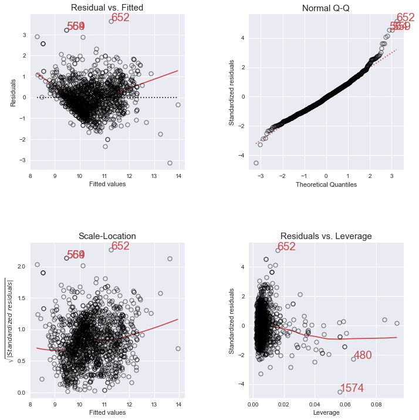

```python
# import lmdiag package
import lmdiag
# plot the diagnostic plots
plt.style.use('seaborn')
plt.figure(figsize=(10,10))
lmdiag.plot(model3)
plt.show();
```

```python
import scipy.stats as stats
stats.shapiro(model3.resid)
```

```
ShapiroResult(statistic=0.9813613891601562, pvalue=1.4858609947900753e-13)
```

# References:

1. Draper, N. R., Smith, H. (1998). Applied Regression Analysis. Wiley Series in Probability and Statistics.
2. Neter, J., Wasserman, W., Kutner, M. H. (1983).Applied Linear Regression Models. Richard D. Irwin, Inc.
3. Seber, G. A. F., Lee, A. J. (2003). Linear Regression Analysis. Wiley Series in Probability and Statistics.
4. https://newonlinecourses.science.psu.edu/stat501/node/2/
5. https://online-learning.harvard.edu/course/data-science-linear-regression
6. https://en.wikipedia.org/wiki/Regression_analysis
7. http://peopleanalytics-regression-book.org/gitbook/
8. https://robert-alvarez.github.io/2018-06-04-diagnostic_plots/
9. https://www.kaggle.com/shrutimechlearn/step-by-step-assumptions-linear-regression